# 政治学方法論Ⅰ：課題３

提出者：吐合大祐（Hakiai Daisuke） 提出日：2014年10月21日

```r
#=================================================
#title: "Research Method Ⅰ of Political Science"
#author: "DaisukeHakiai"
#date: "Monday, October 20, 2014"
#output: html_document
#=================================================
```

### 全問共通

まず、`ggplot`を読み込む。

```r
# Call "ggpolt2" due to creating graphs
require(ggplot2)
```

# 問題１

Q:階乗を計算する関数を作りなさい。

1.関数の名前は `#rmps.factorial` と命名し、引数はxとする。

2. 戻り値はresultであり、掛け算のために最初の段階で1を割り当てる。

3.`if`関数で条件付き分岐をする。

(1.引数が0より小さい場合はエラーメッセージを出力する。（`if(x < 0)`の部分）

(2.引数が0の場合は1が出力されるようにする。(`else if(x == 0)`の部分)

(3.引数が0より大きい場合はべき乗の演算($x!=x(x-1)(x-2)…1$)を行い、その結果を出力するようにする。(`else`の部分)

```r
#=====================
   #問題1
#=====================

#まずRにおける関数"factorial" と同じ機能を持つ関数"rmps.factorial"を定義する。
 rmps.factorial <- function(x){
   #引数はx
   #戻り値はresult

   result <- 1 #戻り値に1を設定する

   if(x < 0){      # 0以下の場合
     #エラーメッセージの表示を設定する。
     print("The argument must be greater than ZERO.")
   }

  else if(x == 0){     # xが0と等しい場合
    　return(1)        # 戻り値は1
  }


  else{                # xが0以上の場合
    for(i in x:1){
      result <- result * i　#　"i"と前出の"result"を掛け合わせる。
    }
    return(result)     # 結果を返す

  }

}
```

#### 最後にRの内蔵関数(`factorial`)と自作関数の結果を比較する

```r
factorial(10) == rmps.factorial(10)
```

```
## [1] TRUE
```

# 問題２

Q:自分で作った階乗の関数を利用して、組み合わせを計算する関数を作りなさい。

1.組み合わせを演算する関数をh.combinationと命名し、因数はnとkとする。 これは、n個のものからk個のものを選ぶことを意味する。

2.`if`関数を条件付き分岐をする。 (1 kがnより大きい場合、0を返す(`if(n<k)`の場合) (2 それ以外の場合は組み合わせの演算を行う(`else`の部分)。 ここで取り上げた組み合わせの公式は$\begin{pmatrix} n \\ k \end{pmatrix}=\frac { n! }{ k!(n-k)! }$である。べき乗の演算は`rmps.factorial`で処理するようにする。

````
(3 結果はresultに書き込まれ、最後にresultの値を返す。(```return(result)```の部分)
````

```r
#==========================
  #問題2
#==========================

#　Rの内蔵関数である"choose"と同等の意味を持つ関数"h.combination"を定義する。
h.combination <- function(n, k){
  # 引数は n, k。
  # 戻り値はresult

 if(n < k){      #　kがnより大きい場合
   return(0)     #戻り値は0とする。

 }

 else{           #　nがkより大きい場合
   #組み合わせを計算する
   result <- rmps.factorial(n) / (rmps.factorial(k) * rmps.factorial(n-k))


   return(result) #戻り値を出す

 }

}
```

#### 最後にRの内蔵関数(`choose`)と自作関数の結果を比較する。

```r
#以下は内蔵関数と自作関数を比較した結果
choose(8,4) == h.combination(8,4)
```

```
## [1] TRUE
```

## 問題3

Q:自分で作った組み合わせの関数を利用して、二項分布の確率質量を求める関数を作りなさい。

1.二項分布の確率質量を求めるユーザー定義関数をh.dbinomと命名し、引数はx,n,pとする。xは成功回数であり、nは試行回数、pは成功確率である。

2．確率質量を求めるために$f\left(x\right)=\begin{pmatrix}n\\x\end{pmatrix}{p}^{x}{(1-p)}^{n-x}\quad(x=0,1,2,…,n)$の演算を行う。組み合わせは問題2で作成した`h.combination`を利用して演算する。

3.最後に結果をresultに書き込み、返す。

```r
#===================
  #問題3
#===================

# Rの内蔵関数である"dbinom"と同じ機能を持つ"h.dbinom"を自作関数として作成する。
h.dbinom <- function(x,n,p){

  #引数：　x - 成功回数
  #　　　　n - 試行回数
  #       p - 成功確率

  #　戻り値はresult

   #　二項分布の確率質量を求める

　result <- h.combination(n, x) * p^x * (1-p)^(n-x)

　return(result)

}
```

#### 最後にRの内蔵関数(`dbinom`)と自作関数の結果を比較する。

```r
#以下が比較した結果
dbinom(1, 8, .4) == h.dbinom(1, 8, .4)
```

```
## [1] FALSE
```

比較した結果、一致していないことが判明した。次に各関数ごとに検証する。

```r
dbinom(1, 8, .4)
```

```
## [1] 0.08957952
```

```r
h.dbinom(1,8, .4)
```

```
## [1] 0.08957952
```

# 問題４

Q:自分で作った二項分布の関数を使い、nが2,3,5,10の場合について、確率質量を図示しなさい。pの値については任意とする。ただし、2つ以上のpで図を作りなさい。その際forループを少なくとも1回使いなさい。

```r
#==================
 #問題4
#==================


#データフレーム"na.data.frame"を作成
na.data.frame <- data.frame(p=NA, n=NA, x=NA, result=NA)
#データフレーム"last.data.frame"を作成。
last.data.frame <- data.frame(p=NULL, n=NULL, x=NULL, result=NULL)
```

成功確率p,試行回数n,成功回数x,それぞれに対してループを使うため3つのfor文を用いる。これらは独立しているわけではなく、三重構造になる。3つ目のfor文の中では臨時データフレーム、na.data.frameにp,n,x,確率質量を書き込み、次は`rbind()`コマンドを使用してlast.data.frameの最終行に追加する。確率質量は問題３のユーザー定義関数である`h.dbinom()`を利用する。

```r
for(p in c(0.3,0.9)){       # p=0.3, p=0.9 とおきループを行う。
  for(i in c(2,3,5,10)){　　　#　n =2,3,5,10とおきループを行う。
    for(j in 0:i){　　　　　　　# x = 0 ~ n　とおきループを行う。

      # p,n,x,確率質量を書き込む
      na.data.frame[1,] <- c(paste("p=", p), paste("n =", i), j, h.dbinom
(j, i, p))

      #二つのデータフレームを結合する。
　　　last.data.frame <- rbind(last.data.frame, na.data.frame)

    }

  }

}
```

この過程で生成されたlast.data.frameのデータを概観しよう。 (最上段、最下段から6行目を表示した。)

```r
#上から6行
head(last.data.frame)
```

```
##        p     n x result
## 1 p= 0.3 n = 2 0   0.49
## 2 p= 0.3 n = 2 1   0.42
## 3 p= 0.3 n = 2 2   0.09
## 4 p= 0.3 n = 3 0  0.343
## 5 p= 0.3 n = 3 1  0.441
## 6 p= 0.3 n = 3 2  0.189
```

```r
#下から6行
tail(last.data.frame)
```

```
##         p      n  x       result
## 43 p= 0.9 n = 10  5 0.0014880348
## 44 p= 0.9 n = 10  6  0.011160261
## 45 p= 0.9 n = 10  7  0.057395628
## 46 p= 0.9 n = 10  8 0.1937102445
## 47 p= 0.9 n = 10  9  0.387420489
## 48 p= 0.9 n = 10 10 0.3486784401
```

ここで、last.data.frameの中身は数値データではなく文字データとして書き込まれている ため、ここでlast.data.frameのn列のデータをfactor型へと変換し、順序付けを行う。

```r
# n の順序付け
last.data.frame$n <- factor(last.data.frame$n,
                             levels = c("n = 2", "n = 3", "n = 5", "n = 10"))
```

```r
prob4.bar1 <- ggplot(data=last.data.frame[1:24,])
prob4.bar2 <- ggplot(data=last.data.frame[25:48,])
```

この基本セットにオプションをつけて表示する。 (ここでは長文のオプションを代替する。)

（以下が、p = 0.3の場合の確率質量の棒グラフを作成する際に入力したコマンド。）

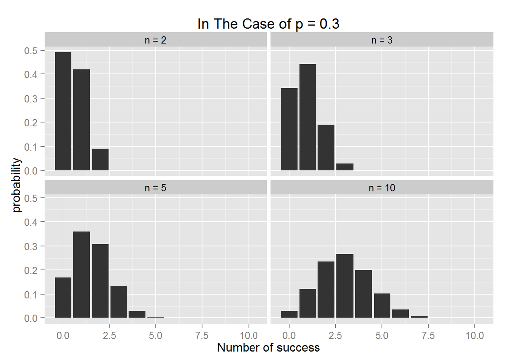

```r
# p = 0.3 の場合
prob4.bar1 + geom_bar(aes(x = as.integer(x), y= as.numeric(result)), stat="identity") +
             facet_wrap(~n) + ylab("probability") + xlab("Number of success") +
             ggtitle("In The Case of p = 0.3")
```

以上がp = 0.3の場合の二項分布の確率質量である。

次に p = 0.9 の場合の確率質量の棒グラフを表示する。 (以下はp=0.9の場合のグラフを作成する際に入力したコマンド。)

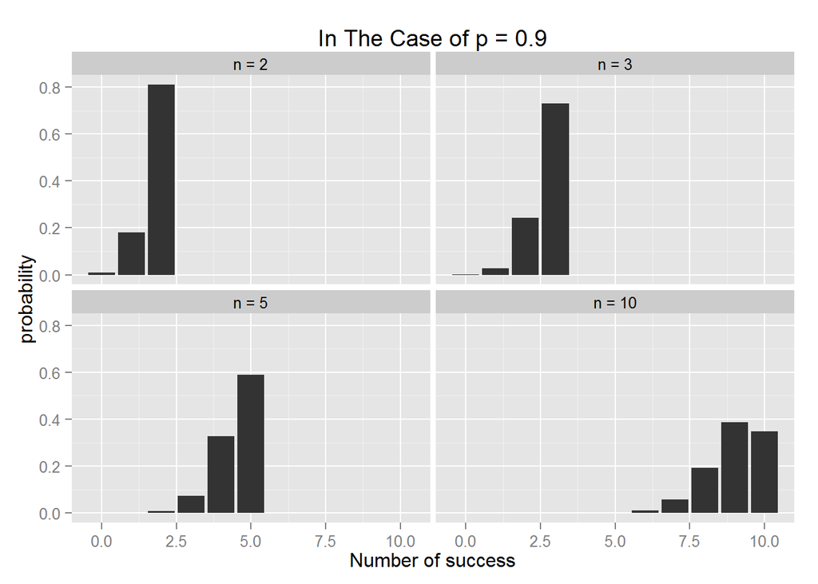

```r
prob4.bar2 + geom_bar(aes(x = as.integer(x), y = as.numeric(result)),stat = "identity") +
         facet_wrap(~n) + ylab("probability") + xlab("Number of success") +
         ggtitle("In The Case of p = 0.9")
```

以上、今週の課題は終了した（と思う）。